# Matplotlib 应用课程

```python
import numpy  as np
import matplotlib.pyplot as plt
```

如果想要把图标真正弄得好看的话，可以添加插件 sciencePlots

```python
# plt.style.use(['science','notebook','grid'])
plt.style.use(['default'])
```

## 快速图表

### 线性图表

简单的命令就可以快速查看数据

```python
x=np.linspace(0,15,30)
y=np.sin(x)+0.1*np.random.randn(len(x))
```

```python
x
```

```
array([ 0.        ,  0.51724138,  1.03448276,  1.55172414,  2.06896552,
        2.5862069 ,  3.10344828,  3.62068966,  4.13793103,  4.65517241,
        5.17241379,  5.68965517,  6.20689655,  6.72413793,  7.24137931,
        7.75862069,  8.27586207,  8.79310345,  9.31034483,  9.82758621,
       10.34482759, 10.86206897, 11.37931034, 11.89655172, 12.4137931 ,
       12.93103448, 13.44827586, 13.96551724, 14.48275862, 15.        ])
```

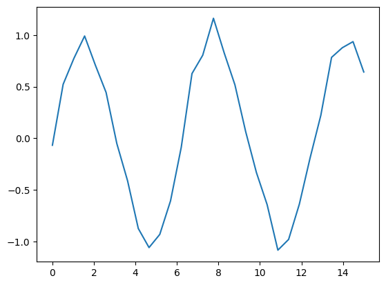

```python
plt.plot(x,y,'-')
```

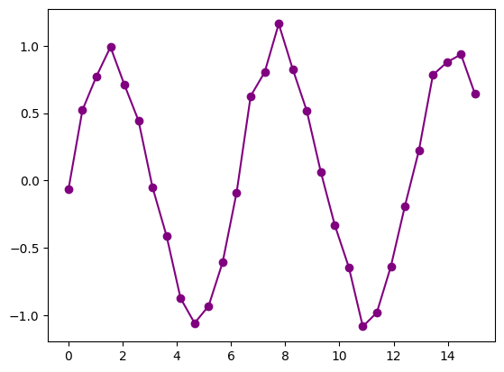

```python
plt.plot(x,y,'o-',color='purple')
```

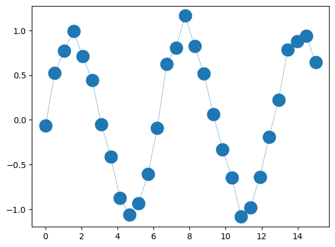

```python
plt.plot(x,y,'o--',lw=0.5,ms=15)
```

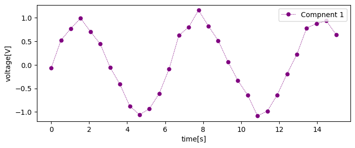

```python
#指定长宽坐标比例
plt.figure(figsize=(8,3))
#打标
plt.xlabel('time[s]')
plt.ylabel('voltage[V]')
#color颜色  lw线宽   ms点大小   label数据线标识
plt.plot(x,y,'o--',color='purple',lw=0.5,ms=5,label='Compnent 1')
#loc标识位置  fontsize字体大小
plt.legend(loc='upper right',fontsize=10 )
```

单表中可以又多个数据线

```python
x2=np.linspace(0,15,100)
y2=np.sin(x2)
```

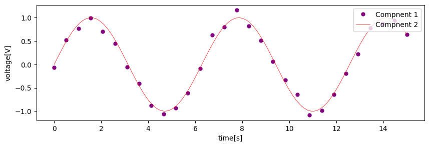

```python
plt.figure(figsize=(10,3))
plt.xlabel('time[s]')
plt.ylabel('voltage[V]')
plt.plot(x,y,'o',color='purple',lw=0.5,ms=5,label='Compnent 1')
plt.plot(x2,y2,'-',color='red',lw=0.5,ms=5,label='Compnent 2')
plt.legend(loc='upper right',fontsize=10)
```

纵横数据限制

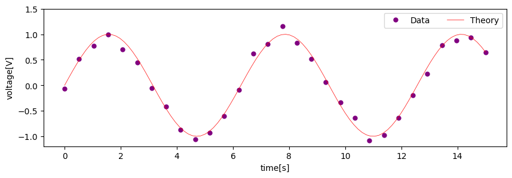

```python
plt.figure(figsize=(10,3))
plt.xlabel('time[s]')
plt.ylabel('voltage[V]')
plt.plot(x,y,'o',color='purple',lw=0.5,ms=5,label='Data')
plt.plot(x2,y2,'-',color='red',lw=0.5,ms=5,label='Theory')
#y轴限制大小
plt.ylim(top=1.5)
#loc标识位置  fontsize字体大小  ncol标识列数量
plt.legend(loc='upper right',fontsize=10,ncol=2)
```

## 直方图

```python
res = np.random.randn(1000)*0.2+0.4
```

快速直方图

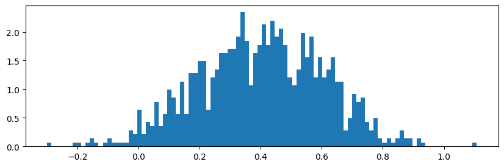

```python
plt.figure(figsize=(10,3))
#bins直方条数量  density分布总和为1
plt.hist(res,bins=100,density=True)
plt.show()
```

不同风格的直方图

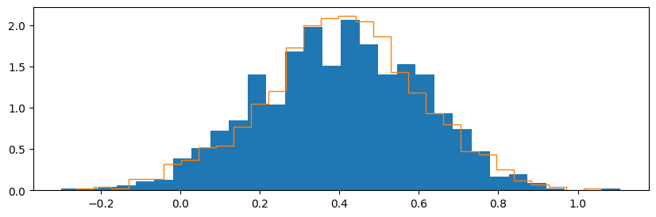

```python
res2 = np.random.randn(1000)*0.2+0.4
plt.figure(figsize=(10,3))
#bins直方条数量  density分布总和为1
plt.hist(res,bins=30,density=True)
# histtype显示上轮廓
plt.hist(res2,bins=30,density=True,histtype='step')
plt.show()
```

## 更高级的 API

对于更复杂的绘图，例如

- 1 个图上的多个子图
- 方便地将文本添加到绘图中
- 创建动画

需要使用稍微高级的 API

### 两个坐标合二为一

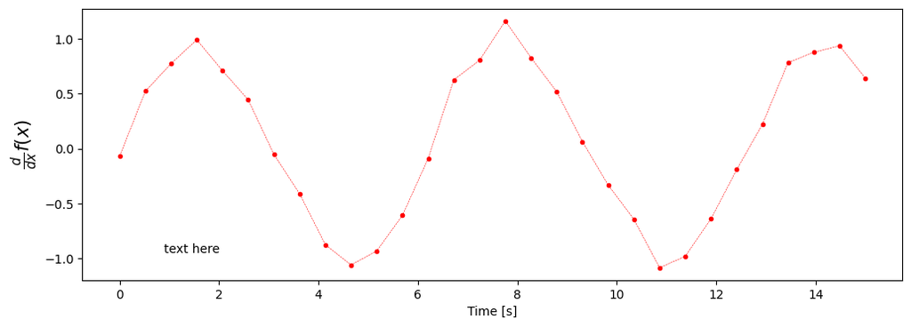

```python
fig, ax = plt.subplots(1, 1, figsize=(12,4))
ax.plot(x, y, 'o--', color='r', lw=0.4, ms=3)
ax.text(0.1, 0.1, 'text here', transform=ax.transAxes)
ax.set_xlabel('Time [s]')
ax.set_ylabel(r'$\frac{d}{dx} f(x)$', fontsize=15)
plt.show()
```

### 单图多坐标轴

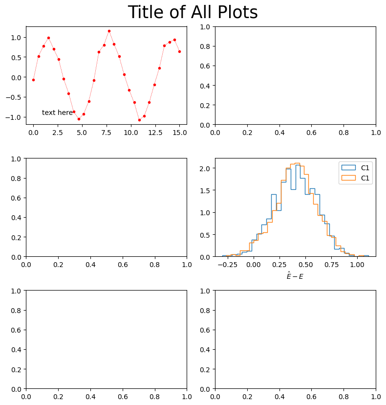

```python
fig, axes = plt.subplots(3, 2, figsize=(8,8))
ax = axes[0][0]
ax.plot(x, y, 'o--', color='r', lw=0.4, ms=3)
ax.text(0.1, 0.1, 'text here', transform=ax.transAxes)
ax = axes[1][1]
ax.hist(res, bins=30, density=True, histtype='step', label='C1')
ax.hist(res2, bins=30, density=True, histtype='step', label='C1')
ax.set_xlabel('$\hat{E}-E$')
ax.legend()
fig.tight_layout()
fig.suptitle('Title of All Plots', y=1.03, fontsize=25)
plt.show()
```

可以使 x 刻度变小

```python
plt.style.use(['science', 'notebook', 'grid'])
fig, ax = plt.subplots(1, 1, figsize=(8,3))
ax.plot(x, y, 'o--', color='r', lw=1, ms=5)
ax.text(0.1, 0.1, 'text here', transform=ax.transAxes)
ax.set_xlabel('Time [s]')
ax.set_ylabel(r'$\frac{d}{dx} f(x)$', fontsize=15)
ax.tick_params(axis='both', which='major', labelsize=10)
ax.grid('minor')
plt.show()
```

[output not shown]

### 例子

源数据给出

```python
res_a1 = 0.2*np.random.randn(1000)+0.4
res_b1 = 0.25*np.random.randn(1000)+0.4
res_a2 = 0.21*np.random.randn(1000)+0.3
res_b2 = 0.22*np.random.randn(1000)+0.3
```

[output not shown]

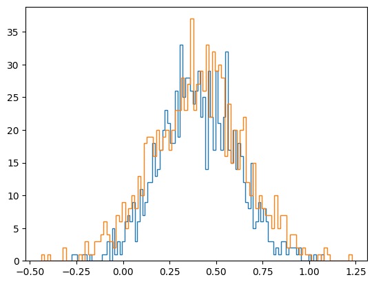

```python
plt.hist(res_a1, bins=100, histtype='step')
plt.hist(res_b1, bins=100, histtype='step')
```

开始前把数据和标识文字整理清楚

```python
textstr1 = '\n'.join((
    r'$\sigma_a=%.4f$' % (np.std(res_a1)),
    r'$\sigma_b=%.4f$' % (np.std(res_b1))))

textstr2 = '\n'.join((
    r'$\sigma_a=%.4f$' % (np.std(res_a2)),
    r'$\sigma_b=%.4f$' % (np.std(res_b2))))
```

```python
textstr2
```

```
'$\\sigma_a=0.2114$\n$\\sigma_b=0.2171$'
```

开始绘制

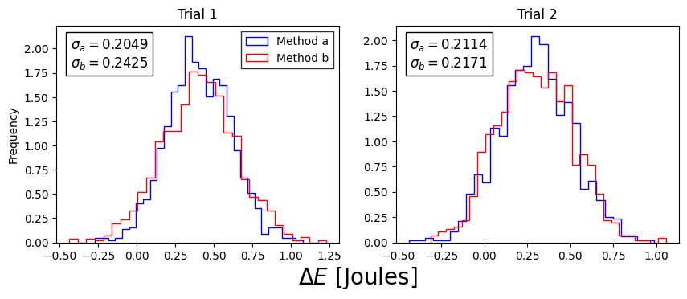

```python
#一行两列的图表
fig, axes = plt.subplots(1, 2, figsize=(10,3.5))
#进入图表1
ax = axes[0]
ax.hist(res_a1, bins=30, density=True, histtype='step', label='Method a', color='blue')
ax.hist(res_b1, bins=30, density=True, histtype='step', label='Method b', color='red')
#facecolor文字背景色
ax.text(0.05, 0.81, textstr1, transform=ax.transAxes,
       bbox=dict(facecolor='white', edgecolor='black'), size=12)

ax.legend(fontsize=10, fancybox=False, edgecolor='black')
ax.set_ylabel('Frequency')
ax.set_title('Trial 1')
#进入图表2
ax = axes[1]
ax.hist(res_a2, bins=30, density=True, histtype='step', label='Method 1', color='blue')
ax.hist(res_b2, bins=30, density=True, histtype='step', label='Method 2', color='red')
ax.text(0.05, 0.81, textstr2, transform=ax.transAxes,
       bbox=dict(facecolor='white', edgecolor='black'), size=12)
ax.set_title('Trial 2')

fig.text(0.5, -0.04, '$\Delta E$ [Joules]', ha='center', size=20)
plt.savefig('trial.png', dpi=200)
plt.show()
```

## 2D图表

搞来些数据

```python
plt.style.use(['default'])
```

```python
_ = np.linspace(-1, 1, 100)
x, y = np.meshgrid(_,_)
z = x**2+x*y
```

```python
z
```

```
array([[ 2.00000000e+00,  1.93980206e+00,  1.88042037e+00, ...,
        -3.87715539e-02, -1.97938986e-02,  0.00000000e+00],
       [ 1.97979798e+00,  1.92000816e+00,  1.86103459e+00, ...,
        -1.93857770e-02,  1.11022302e-16,  2.02020202e-02],
       [ 1.95959596e+00,  1.90021426e+00,  1.84164881e+00, ...,
         2.22044605e-16,  1.97938986e-02,  4.04040404e-02],
       ...,
       [ 4.04040404e-02,  1.97938986e-02, -2.22044605e-16, ...,
         1.84164881e+00,  1.90021426e+00,  1.95959596e+00],
       [ 2.02020202e-02, -1.11022302e-16, -1.93857770e-02, ...,
         1.86103459e+00,  1.92000816e+00,  1.97979798e+00],
       [ 0.00000000e+00, -1.97938986e-02, -3.87715539e-02, ...,
         1.88042037e+00,  1.93980206e+00,  2.00000000e+00]])
```

### 填充等高线

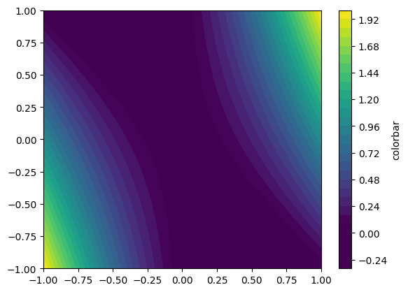

```python
#vmin最低截断 以下为同色   vmax最高截断 以上为同色
plt.contourf(x,y,z,levels=30,vmin=0.1)
plt.colorbar(label='colorbar')
```

可以使它们更密集，可以改变色阶，也可以改变颜色图

查看 https://matplotlib.org/stable/tutorials/colors/colormaps.html#sphx-glr-tutorials-colors-colormaps-py

可以使用 vmin 和 vmax 来调整颜色范围

请参阅 https://matplotlib.org/stable/api/_as_gen/matplotlib.pyplot.contour.html 了解所有设置

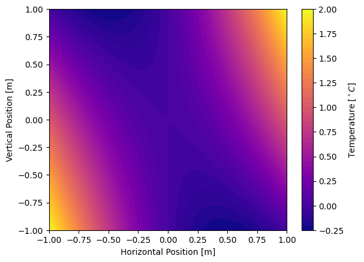

```python
#整出个热度图
plt.contourf(x,y,z, levels=50, cmap='plasma')
plt.colorbar(label='Temperature [$^\circ C$]')
plt.xlabel('Horizontal Position [m]')
plt.ylabel('Vertical Position [m]')
```

## 等高线图

如下数据

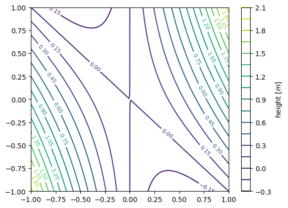

```python
cs = plt.contour(x,y,z, levels=20)
plt.clabel(cs, fontsize=8)
plt.colorbar(label='height [$m$]')
```

### 3D曲面图表

3D 曲面图（matplotlib通常不是首选）。但是，它们在动画中往往效果很好（我们稍后会谈到这一点）

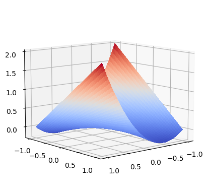

```python
#创建3D空间
fig, ax = plt.subplots(subplot_kw={"projection": "3d"})
ax.plot_surface(x,y,z, cmap='coolwarm',
                       linewidth=0, antialiased=False)
ax.view_init(elev=10, azim=50)
```

### 流图

用于绘制向量场

```python
w = 3
_ = np.linspace(-3,3,100)
X, Y = np.meshgrid(_,_)
U = -1 - X**2 + Y
V = 1 + X - Y**2
speed = np.sqrt(U**2 + V**2)
```

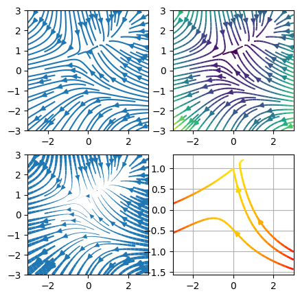

```python
#4x4表
fig, axes = plt.subplots(2,2,figsize=(5,5))
ax = axes[0][0]
ax.streamplot(X, Y, U, V)
ax = axes[0][1]
ax.streamplot(X, Y, U, V, color=speed)
ax = axes[1][0]
lw = 5*speed / speed.max()
ax.streamplot(X, Y, U, V, linewidth=lw)
ax = axes[1][1]
seed_points = np.array([[0,1], [1,0],[-1,-0.2]])
ax.streamplot(X, Y, U, V, color=U, linewidth=2,
                      cmap='autumn', start_points=seed_points)
ax.grid()
```

### 图像读取

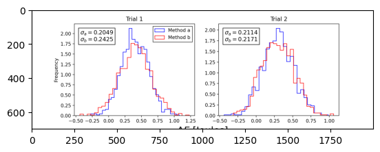

```python
im = plt.imread('trial.png')
plt.imshow(im)
```

## 动画

动画需要将问题的时间与动画帧相关联，然后指定每秒的帧数

下面是一个 波浪以 3m/s 的速度移动。将其转换为动画

```python
def f(x,t):
    return np.sin(x-3*t)

x = np.linspace(0, 10*np.pi, 1000)
t = np.arange(0, 24, 1/60)
X, T = np.meshgrid(x, t)
F = f(X, T)
```

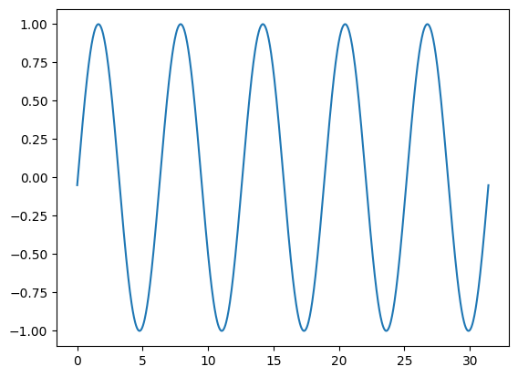

```python
plt.plot(x, F[1])
```

创建动画

```python
from matplotlib import animation
from matplotlib.animation import PillowWriter
```

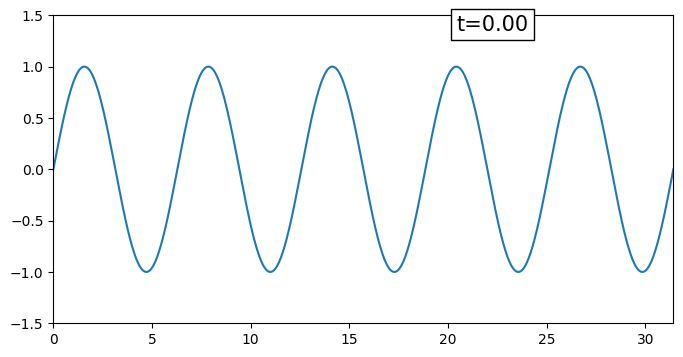

```python
fig, ax = plt.subplots(1,1, figsize=(8,4))
ln1, = plt.plot([], [])
time_text = ax.text(0.65, 0.95, '', fontsize=15,
                    bbox=dict(facecolor='white', edgecolor='black'),
                    transform=ax.transAxes)
ax.set_xlim(0,10*np.pi)
ax.set_ylim(-1.5, 1.5)

def animate(i):
    ln1.set_data(x, F[i])
    time_text.set_text('t={:.2f}'.format(i/60))

ani = animation.FuncAnimation(fig, animate, frames=240, interval=50)
ani.save('ani.gif',writer='pillow',fps=50,dpi=100)
ani
```

动画功能也可以以其他方式使用。可以创建表面的 3D 旋转 GIF。

```python
_ = np.linspace(-1, 1, 100)
x, y = np.meshgrid(_,_)
z = x**2+x*y
```

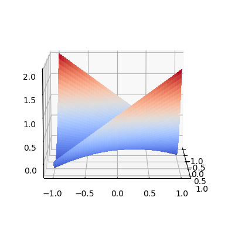

```python
fig, ax = plt.subplots(subplot_kw={"projection": "3d"})
ax.plot_surface(x,y,z, cmap='coolwarm',
                       linewidth=0, antialiased=False)
ax.view_init(elev=10, azim=0)

def animate(i):
    ax.view_init(elev=10, azim=3*i)

ani = animation.FuncAnimation(fig, animate, frames=120, interval=50)
ani.save('ani2.gif',writer='pillow',fps=30,dpi=100)
```